# Soil Health Discussion

Tyson Hart

4/10/2020

## Introduction

Of all the statistical methods, selecting through the metrics in the boxplots provides the quickest and most relatable way of visualizing the data. The boxplots show clear significant differences when the body of one boxplot is completely above or below another. Haney’s Soil Health Calculation (S.H.C.), SFA’s pH, Calcium (Ca), and Manganese (Mn), Ward’s diversity index (Div.Ind), total micorobial biomass (Bio.Tot), and an all-varialbe principal components analysis (PCA) show useful results.

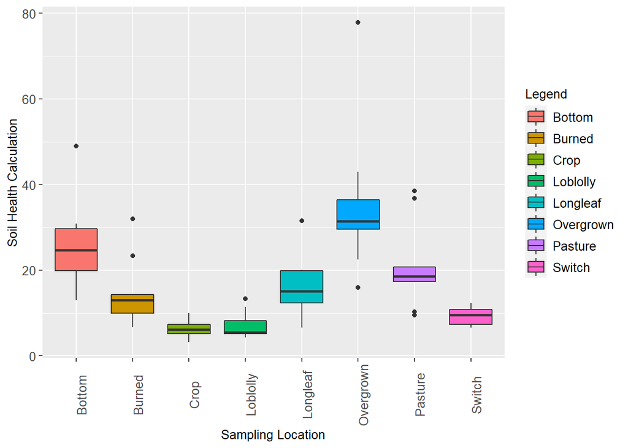

## Soil Health Calculation

Haney’s Soil Health Calculation takes into account three weighted variables, the carbon dioxide released from the microbes in 24 hours after drying and rewetting, organic carbon, and organic nitrogen. The results show a clear separation in the Overgrown site and followed closely by the Bottom site. These two locations have been undisturbed for decades and clearly have the most developed microbial communities. Organic matter is constantly built up in the Overgrown site by allowing for continuous growth in a diverse natural state. The Bottom site is the lowest on the landscape, prone to flooding, and is a carbon and nitrogen sink. The microbes that populate the soil must be adapted to ever-changing conditions, but their nutrient availability is constant. The Burned, Longleaf, and Pasture sites represent a median area, while the Crop, Loblolly, and Switch site have the lowest values.

## pH

| Location | pH Med | pH Min | pH Max | pH SdDv |
| --- | --- | --- | --- | --- |
| Bottom | 4.94 | 4.60 | 5.53 | 0.29 |
| Burned | 5.83 | 5.60 | 6.31 | 0.21 |
| Crop | 5.71 | 5.24 | 6.16 | 0.27 |
| Loblolly | 5.58 | 4.75 | 5.74 | 0.35 |
| Longleaf | 5.35 | 4.49 | 6.22 | 0.59 |
| Overgrown | 7.24 | 6.73 | 7.62 | 0.28 |
| Pasture | 6.83 | 6.41 | 7.42 | 0.32 |
| Swith | 5.73 | 5.28 | 5.99 | 0.25 |

Soil pH affects the ability for plants to absorb nutrients. Soils in east Texas are generally acidic due to high amounts of rainfall. The pH range for all sampled sites across all seasons was 4.49 to 7.62. The Bottom had the lowest median pH of 4.94. The Longleaf, Loblolly, Crop, Switch, and Burned site had median pH values between 5.35 and 5.83. The Pasture had a median value of 6.83 and the Overgrown site had the highest pH of 7.24.

## Nutrient Availabilty by pH

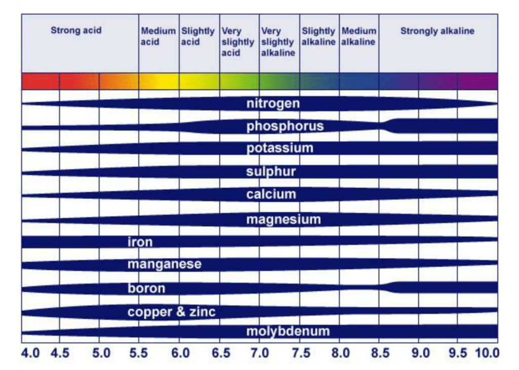

## Calcium

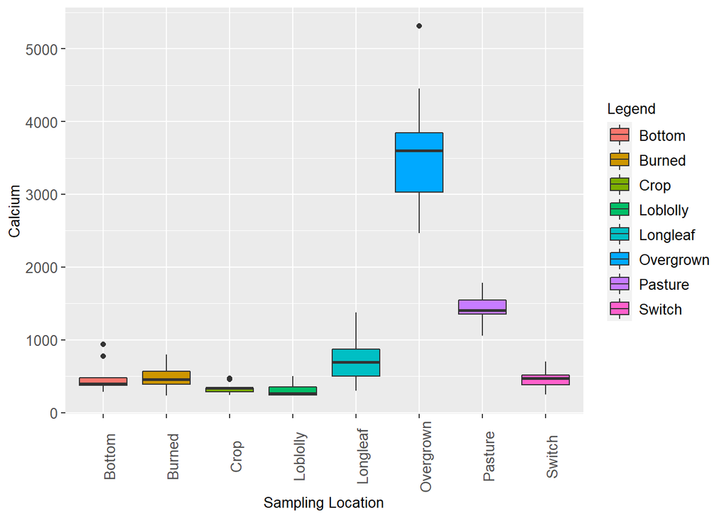

## Manganese

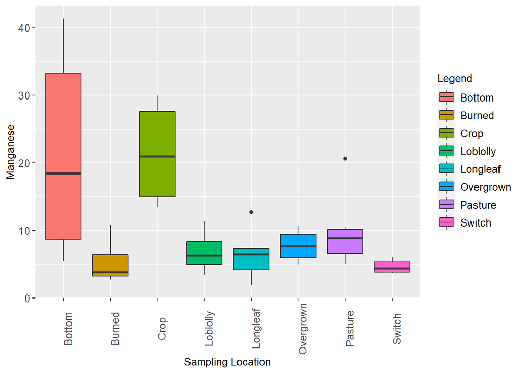

## Diversity Index by Sampling Season

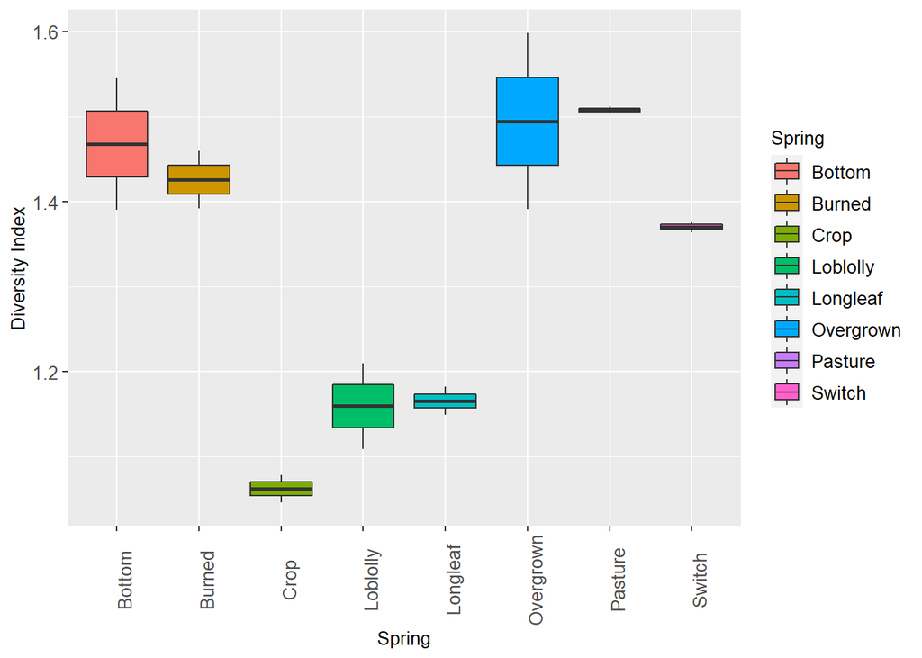

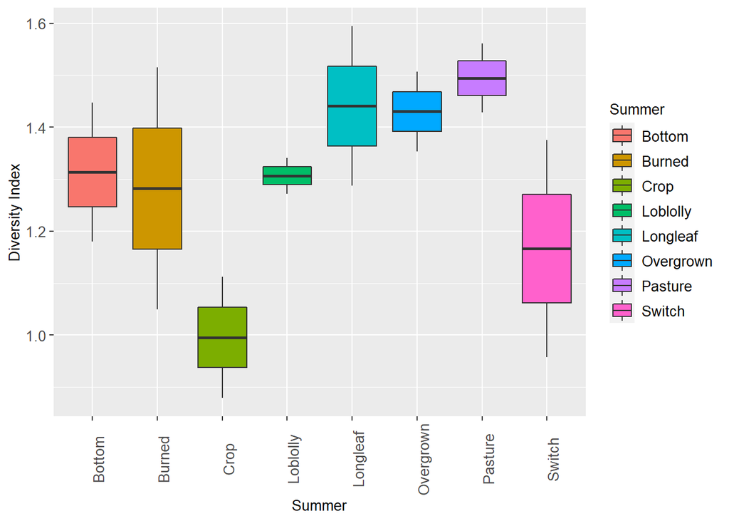

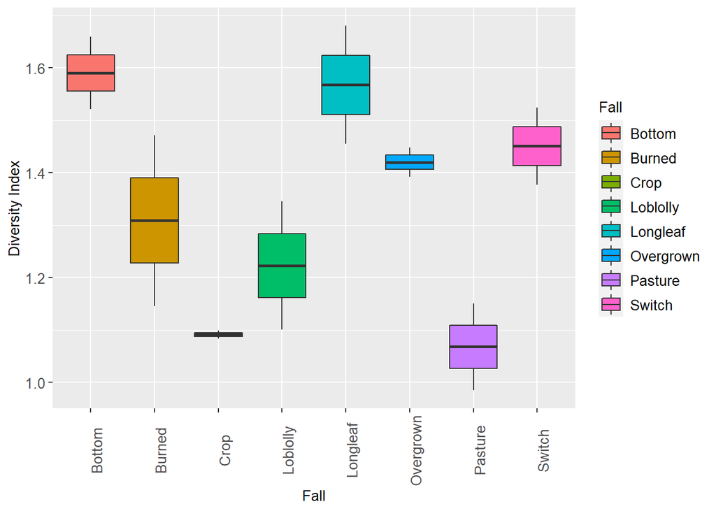

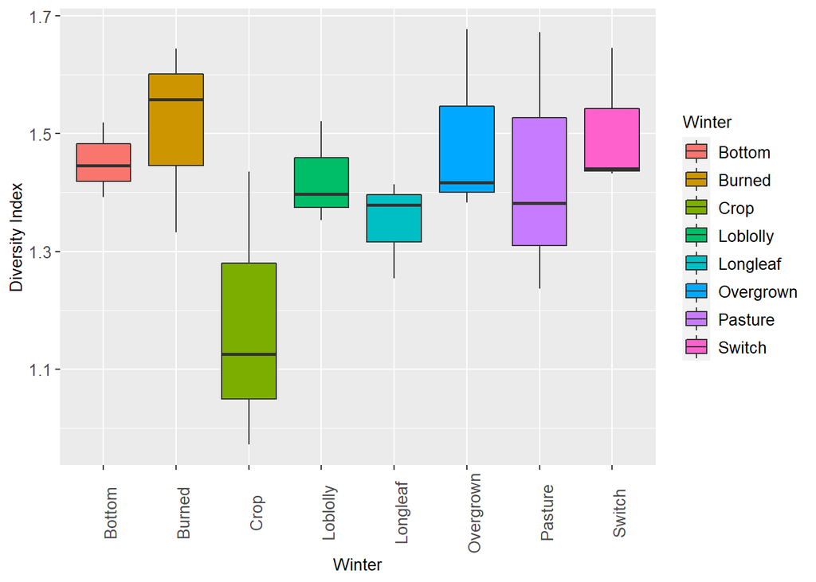

Ward’s Diversity Index had a definitive seasonal component. During the spring, the Bottom, Burned, Overgrown, Pasture, and Switch sites had significantly higher values than the Crop, Loblolly, and Longleaf sites. The summer sampling all had similar values except the Crop field, which was significantly lower. The fall again showed variability with three groupings; the Bottom, Longleaf, Overgrown, and Switch sites were the highest; the Burned and Loblolly occupied the middle; the Crop and Pasture sites were significantly lower. Lastly, the winter mirrored the summer with similar values except a significantly lower index in the Crop site. The variability is possibly associated with aboveground growth. Observationally, the Bottom, Burned, and Overgrown sites have the highest plant density and diversity and at least one species of plant is green (not dormant) during the seasons of sampling.

## Total Microbial Biomass

| Location | Bio Med | Bio Min | Bio Max | Bio SdDv |
| --- | --- | --- | --- | --- |
| Bottom | 5,827 | 3,713 | 35,147 | 9,854 |
| Burned | 3,464 | 2,302 | 4,716 | 1,036 |
| Crop | 1,033 | 322 | 1,769 | 397 |
| Loblolly | 2,379 | 1,463 | 4,176 | 991 |
| Longleaf | 3,031 | 1,366 | 13,908 | 3,926 |
| Overgrown | 8,509 | 4,528 | 10,853 | 2,186 |
| Pasture | 4,226 | 3,107 | 7,406 | 1,439 |
| Swith | 2,542 | 1,220 | 5,969 | 1,685 |

Ward’s measure of total microbial biomass paints a distinct picture of underground activity. The Overgrown site had the highest median total biomass of 8,509 ng/g and the Crop site had the lowest with 1,033 ng/g. The biomass totals reflect the diversity index increase with aboveground plant species. The total biomass at the Burned site was close to both the Loblolly and Longleaf sites. This is surprising because all historical accounts and current land management recommendations include a frequent fire prescription. Further reading and research needs to be conducted to learn more of the role of fire in microbial communities.

## Correlation

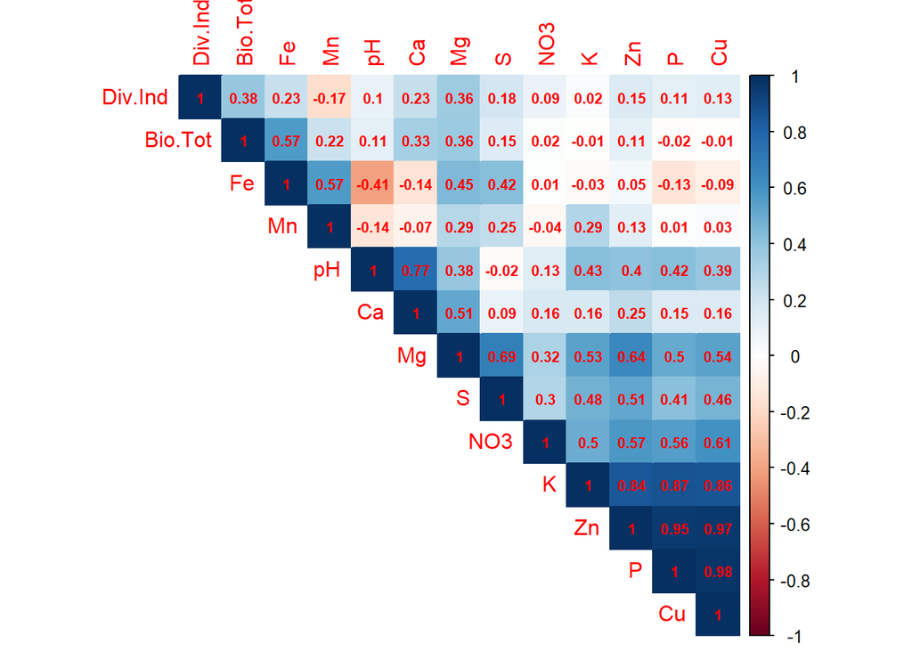

## Principal Components Analysis (PCA)

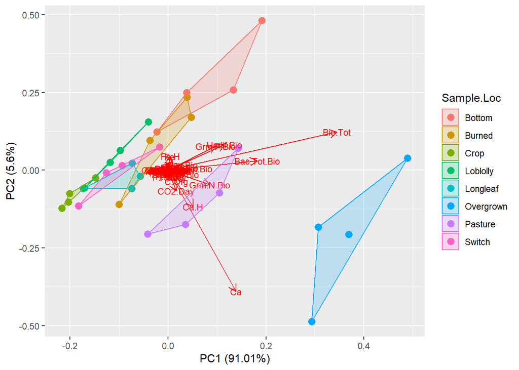

## Conclusion

This soil is good versus this soil is bad can only go so far in the justification of what is truly healthy or not. The data provided by the study begins to give a quantitative way of showcasing what conservationists have been describing qualitatively for years. Further elucidation of this data can begin to shed light on what metrics can help truly qualifying which east Texas soils are healthy. And if the site is deemed unsatisfactory by the land manager’s standards, what enhancements can be made. This tool was built to quickly compare a complicated set of variables in a complex environment. By getting the ball rolling, the hope is others will take time to provide insights to their analysis. All thoughts are welcome as more perspectives allow for healthy discussion.